# Lecture 6 - TD Reinforcement Learning

Author: Matthew J. Crossley

Last update: 01 April, 2021

## Reinforcement learning framework

- An agent can occupy a discrete set of states $S$ and can take a discrete set of actions $A$ from each state as determined by some policy $\pi$.

$$S = \{s_1, s_2, \ldots, s_n\} \\
A = \{a_1, a_2, \ldots, a_n\} \\
\pi \rightarrow P(a_i | s_j)$$

- The actions $a_i$ taken by the agent determine the probability that the state will transition from $s_i$ to $s_j$, and also determine the probability of current and future reward (because rewards are causally determined by states).
- The goal of the agent is to learn to take actions that maximize current and future reward. That is, the RL agent tries to determine the state-value function $V_{\pi}(s)$ of a given policy $\pi$ as a function of each state $s$.

$$\begin{align}
V_{\pi}(s) &= \operatorname{E}[R | \pi, s] \nonumber \\
&= \operatorname{E} \left[ \sum_{t=0}^{\infty} \gamma^t r_t | \pi, s \right].
\end{align}$$

- Here, $\gamma$ is a temporal discounting factor that allows the agent to care more about near rewards than about distant future rewards.
- The fundamental goal of RL is to estimate $V_{\pi}(s)$ using nothing more than the experience an agent gains while navigating its environment. The specific way in which an RL algorithm does this varies greatly from one algorithm to the next, and is still very much an active area of research.

## Estimating the state-value function

- RL aims to learn state-value function through experience.
- The general structure is to give the agent many trials of experience, where on each trial the agent visits some sequence of states by taking some sequence of actions.
- A trial of experience comes to an end whenever a terminal state is visited, but in principle, goes on forever until such a state is experienced.
- The layout of an RL program will generally look something like the following:

```python
import numpy as np
import matplotlib.pyplot as plt

n_trials = 10

# specify the set of states
states = np.array([1, 2, 3])
n_states = states.shape[0]

# initialise value estimate
v = np.zeros((n_trials, n_states))

for trial in range(n_trials):

  terminate = False
  while not terminate:
    # select action (using policy pi)

    # transition to new state (determined by environment)

    # possibly receive reward (determined by environment)

    # update value estimate of newly arrived in state
    # (variety of RL algorithms for this -- e.g., TD
    # learning (see below))

    # check if current state is terminal
    # if s == 3:
    #   terminate = True

    # for now just set to True to avoid infinite while loop
    terminate = True
```

## Temporal difference (TD) learning

- TD RL estimates the state-value function under the assumption that the action policy is fixed.
- The term *temporal* in TD learning refers to the difference between successive visits to a particular state (across trials), not *necessarily* across different times within a trial.
- TD learning simply tries to iteratively update its estimate of a states value by directly experiencing them, comparing what was experienced to what was expected, and updating its expectation to more closely match recent experience.
- Let $n$ index the current trial, $s$ be the state just arrived in, $s'$ be the next future state (knowable because TD assumes a fixed action selection policy), and $\hat{V}_{n}(s)$ be the state-value function estimate on trial $n$ of state $s$.
- TD learning updates the state-value function across trials as follows:

$$\begin{equation}
\hat{V}_{n}(s) = \hat{V}_{n-1}(s) +
\alpha (r_{n}(s) + \gamma \hat{V}_{n-1}(s') - \hat{V}_{n-1}(s)).
\end{equation}$$

- The term $r_{n}$ is the reward that was delivered upon arrival to the current state $s'$.
- $\hat{V}_{n-1}(s')$ is the reward that is expected to arrive in *future* states visited beyond $s'$. This value has to come from the the state-value function estimate in the previous trial $n-1$ because the agent has not yet experienced states beyond $s'$ in the current trial.
- $\alpha$ is called the learning rate and $\gamma$ is the temporal discounting parameter.
- Notice that you can write the value update as follows:

$$\begin{equation}
\hat{V}_{n}(s) =
(1-\alpha) (\hat{V}_{n-1}(s)) +
\alpha (r_{n}(s) + \gamma \hat{V}_{n-1}(s')).
\end{equation}$$

- In this form it may be easier to see that the update to our estimate of the state-value function is a weighted average of whatever it was on the previous trial with whatever current reward was experienced and future reward is expected from the newly arrived in state $s'$.

### TD RL model of classical conditioning

- Consider the classic Pavlov’s dog experiment.
- States are taken to be time steps between cue onset and reward delivery, which occurs on every trial at time step $T$ with magnitude $r$.
- The value update equation then becomes:

$$\begin{equation}
\hat{V}_{n}(t) = \hat{V}_{n-1}(t) +
\alpha (r_{n}(t) + \gamma \hat{V}_{n-1}(t+1) - \hat{V}_{n-1}(t))
\end{equation}$$

- To get a feel for how this works, consider the first few trials.
- $n=1, t=T$

$$\begin{align}
\hat{V}_{1}(T) &= \hat{V}_{0}(t) + \alpha (r_{1}(T) + \gamma \hat{V}_{0}(T+1) - \hat{V}_{0}(T)) \\
&= \alpha r
\end{align}$$

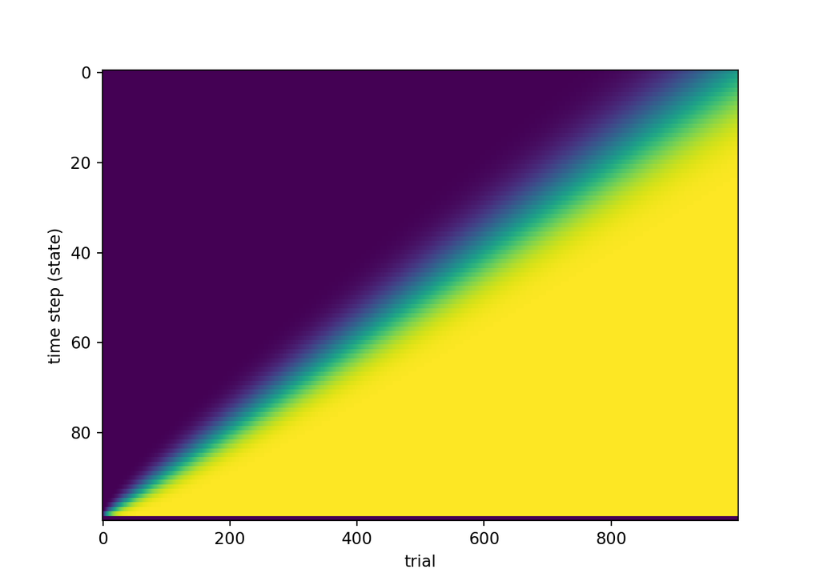

```python
import numpy as np
import matplotlib.pyplot as plt

n_trials = 1000
n_steps = 100

v_init = 0.0

alpha = 0.1
gamma = 1

v = np.zeros((n_steps, n_trials))
v[:, 0] = v_init

for n in range(1, n_trials):
    for t in range(n_steps - 1):
        s = t
        sprime = t + 1
        r = 1 if s == (n_steps - 2) else 0
        v[s, n] = v[s, n - 1] + alpha * (r + gamma * v[sprime, n - 1] - v[s, n - 1])

fig, ax = plt.subplots(1, 1, squeeze=False)
ax[0, 0].imshow(v, aspect='auto')
ax[0, 0].set_xlabel('trial')
ax[0, 0].set_ylabel('time step (state)')
plt.show()
```

### TD RL in a simple 2-arm bandit task

- This is a very simple scenario in which the agent begins in state $s_0$ and can select only one of two actions. Action $a_1$ selects the slot machine on the left and leads to state $s_l$, and action $a_2$ selects the slot machine on the right and leads to state $s_r$. Reward is delivered in state $s_l$ and $s_r$ with different probability, and both are terminal states.
- Let $n$ index the current trial and $\hat{V}_{n}(s)$ be the state-value function estimate on trial $n$ of state $s\in\{s_l,s_r\}$. In the 2-armed bandit task descirbed above, TD iteratively updates its estimate of $\hat{V}_{n}(s)$ according to the following:

$$\begin{equation}
\hat{V}_{n}(s) = \hat{V}_{n-1}(s) + \alpha (r_{n} - \hat{V}_{n-1}(s)).
\end{equation}$$

- The rightmost term $r_{n} - \hat{V}_{n-1}(s)$ is called the reward prediction error (RPE).
- Conceptually, RPE is simply the difference between the obtained and expected reward.
- It is easy to see that learning a good estimate of the value function is equivalent to eliminating RPE.
- RPE is often notated as $\delta$, so we can write $\delta_{n}=r_{n}-\hat{V}_{n-1}(s)$.
- You can also write the value update equation in the following form:

$$\begin{equation}
\hat{V}_{n}(s) = (1-\alpha) \hat{V}_{n-1}(s) + \alpha r_{n}.
\end{equation}$$

- In this form it may be easier to see that the update to our estimate of the state-value function is a weighted average of whatever it was on the previous trial with whatever current reward was experienced.
- In code, a TD agent performing a 2-armed bandit task looks as follows:

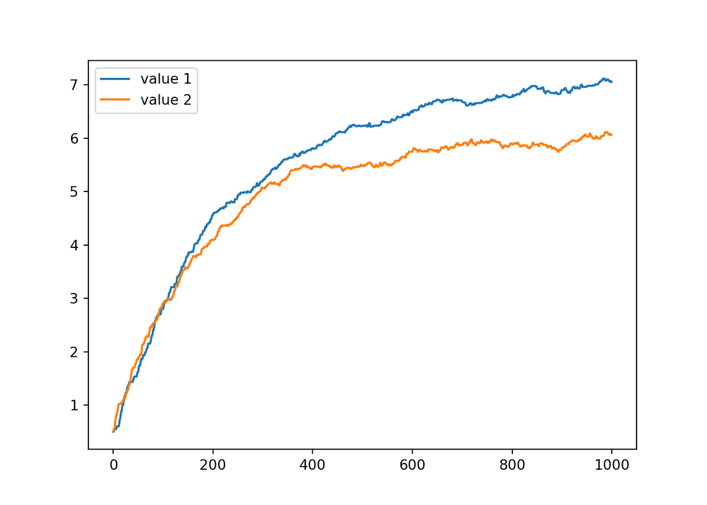

```python
import numpy as np
import matplotlib.pyplot as plt

n_trials = 1000

v_init = 0.5
p_reward_1 = 7
p_reward_2 = 6
alpha = 0.01
epsilon = 0.2

v = np.zeros((2, n_trials))
v[:, 0] = v_init

for i in range(0, n_trials - 1):

    # action selection - guessing
    if np.random.uniform() < 0.5:
        # reward
        r = np.random.normal(p_reward_1, 2)

        # reward prediction error
        delta = r - v[0, i]

        # value update
        v[0, i + 1] = v[0, i] + alpha * delta
        v[1, i + 1] = v[1, i]

    else:
        # reward
        r = np.random.normal(p_reward_2, 2)

        # reward prediction error
        delta = r - v[1, i]

        # value update
        v[1, i + 1] = v[1, i] + alpha * delta
        v[0, i + 1] = v[0, i]

fig, ax = plt.subplots(1, 1, squeeze=False)
ax[0, 0].plot(v[0, :], label='value 1')
ax[0, 0].plot(v[1, :], label='value 2')
plt.legend()
plt.show()
```

### Action selection policy

- We saw above that even if the agent simply guesses at each bandit, never modifying its action selection strategy to reflect its updating beliefs about the value of the the two options, the estimate of the value function still approaches the true value.
- This makes clear that some amount of guessing (i.e., exploration) is good for learning the value function, but perhaps not so great for actually maximising the obtained rewards (the actual goal of an RL agent).
- Two popular action selection policies attempt to balance exploration with exploitation.

#### Epsilon greedy

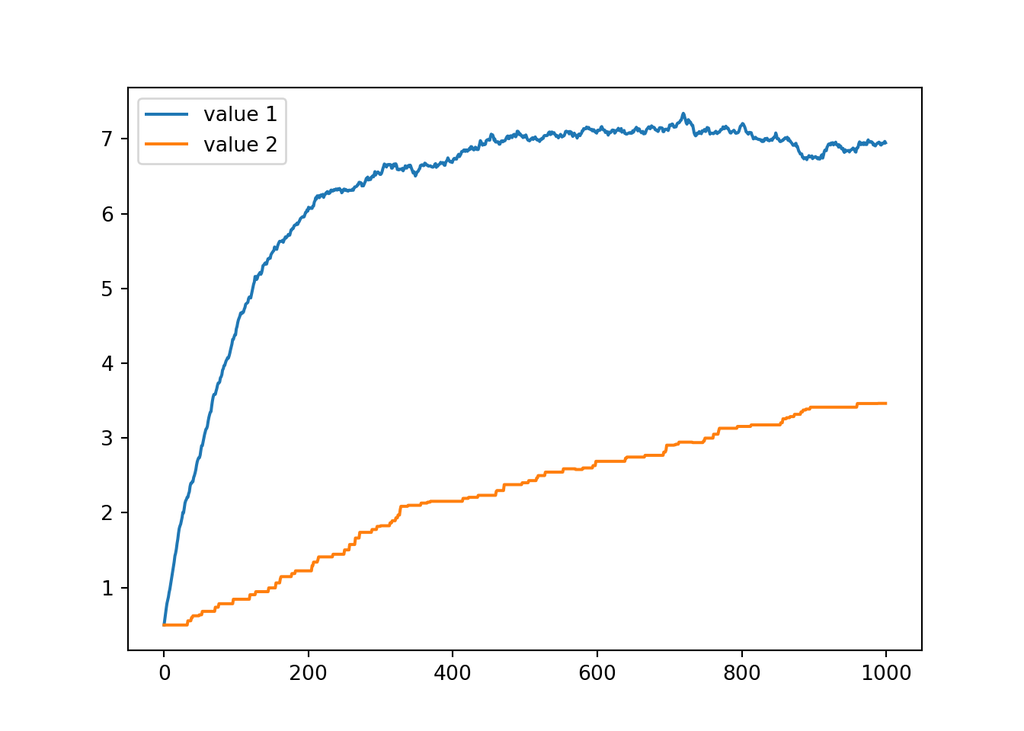

```python
import numpy as np
import matplotlib.pyplot as plt

n_trials = 1000

v_init = 0.5
p_reward_1 = 7
p_reward_2 = 6
alpha = 0.01
epsilon = 0.2

v = np.zeros((2, n_trials))
v[:, 0] = v_init

for i in range(0, n_trials - 1):

    # action selection - greedy epsilon
    if np.random.uniform() < epsilon:
        a = np.round(np.random.uniform())
    else:
        a = np.argmax(v[:, i])

    if a == 0:
        # reward
        r = np.random.normal(p_reward_1, 2)

        # reward prediction error
        delta = r - v[0, i]

        # value update
        v[0, i + 1] = v[0, i] + alpha * delta
        v[1, i + 1] = v[1, i]

    else:
        # reward
        r = np.random.normal(p_reward_2, 2)

        # reward prediction error
        delta = r - v[1, i]

        # value update
        v[1, i + 1] = v[1, i] + alpha * delta
        v[0, i + 1] = v[0, i]

fig, ax = plt.subplots(1, 1, squeeze=False)
ax[0, 0].plot(v[0, :], label='value 1')
ax[0, 0].plot(v[1, :], label='value 2')
plt.legend()
plt.show()
```

#### Softmax

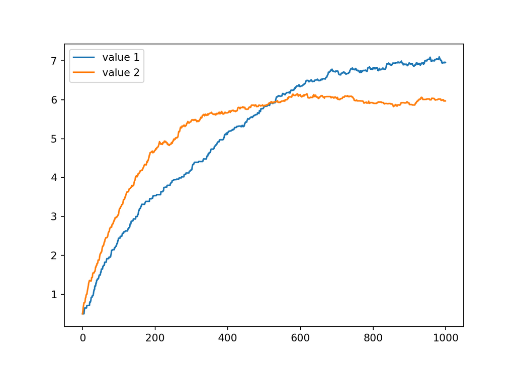

```python
import numpy as np
import matplotlib.pyplot as plt

n_trials = 1000

v_init = 0.5
p_reward_1 = 7
p_reward_2 = 6
alpha = 0.01
epsilon = 0.2

v = np.zeros((2, n_trials))
v[:, 0] = v_init

for i in range(0, n_trials - 1):

    # action selection - softmax
    sm = np.exp(v[:, i]) / np.sum(np.exp(v[:, i]))
    if np.random.uniform() < sm[0]:
        # reward
        r = np.random.normal(p_reward_1, 2)

        # reward prediction error
        delta = r - v[0, i]

        # value update
        v[0, i + 1] = v[0, i] + alpha * delta
        v[1, i + 1] = v[1, i]

    else:
        # reward
        r = np.random.normal(p_reward_2, 2)

        # reward prediction error
        delta = r - v[1, i]

        # value update
        v[1, i + 1] = v[1, i] + alpha * delta
        v[0, i + 1] = v[0, i]

fig, ax = plt.subplots(1, 1, squeeze=False)
ax[0, 0].plot(v[0, :], label='value 1')
ax[0, 0].plot(v[1, :], label='value 2')
plt.legend()
plt.show()
```